# Pooling effect sizes

Common-effect, random-effects and multilevel models — and how to show the results

Damien Beillouin

CIRAD, UPR HortSys

## Learning objectives

By the end of this session, you will be able to:

1. Explain why studies are **weighted**, and how the weights change between models.
2. Distinguish **common-effect**, **random-effects** and **multilevel** models — and choose one **before** seeing the data.
3. Read **μ, its CI, τ², I² and the prediction interval**, and say which answers which question.
4. Fit and plot them in R with `metafor` (practical, 33 min).

## Where we are

This morning, `escalc()` gave us, for each of the **382** comparisons of pest abundance:

- `yi`: the lnRR (effect size)
- `vi`: its sampling variance

These come from **28 studies**.

This afternoon’s question How do we turn 382 numbers into **one answer** — and an honest statement of **how certain** and **how variable** it is?

Plain average of the 382 lnRR: **-24%**. Why is that a bad answer? *(think 20 s)*

# Weights and models

## Two views of the world

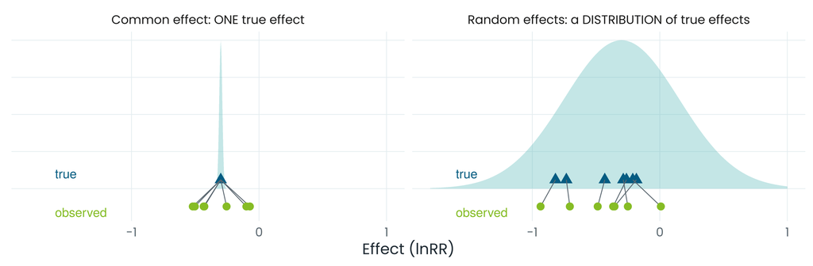

$y_k = \mu + \varepsilon_k$ — studies differ **only** by sampling error.  
Also called “fixed-effect” or “equal-effects” (`method = "EE"`).

$y_k = \mu + u_k + \varepsilon_k$, with $\text{Var}(u_k) = \tau^2$ — true effects **really differ** (soils, climates, pests…).

## Weights: precise studies count more

Common effect:
$$w_k = \frac{1}{v_k}$$

Random effects:
$$w_k = \frac{1}{v_k + \tau^2}$$

Adding τ² to every variance makes the weights **more equal**: very precise studies dominate less.

| Share of the total weight | Common effect | Random effects |
| --- | --- | --- |
| Zhou 2013 (51 very precise rows) | **76%** | 17% |
| Maluleke 2005 (80 rows) | 23% | **26%** |

Common effect: **2 studies out of 28 carry 99%** of the weight.  
Random effects: τ² tames the *precise* studies — but a study with **many rows** still counts a lot. That is the next problem.

Source: Zhou et al. (2013); Maluleke et al. (2005); via Jones et al. (2021).

## Which model? Decide **before** seeing the data

Show of hands

Q is significant (p < 0.001). Should I **switch** from a common-effect to a random-effects model?

**No — the choice is conceptual, not a test result.** Do you want to generalise beyond these exact studies? Do you expect true effects to differ (sites, species, practices)? In ecology and agronomy: **yes and yes → random effects, stated in the protocol.** The Q test has low power with few studies and is almost always significant with many.

# Heterogeneity

## Three numbers, three meanings

|  | Meaning | Our pests (random-effects model, dependence ignored for now) |
| --- | --- | --- |
| **τ²** (τ) | Variance (SD) of the **true** effects, in lnRR units | τ = 0.58 |
| **I²** | Share of the observed variance **not** due to sampling error — a *relative* measure | 99.9% |
| **Q** | Test of “all true effects are equal” | p < 0.001 |

**I² ≈ 100% does not mean “huge differences”**: it means sampling error is tiny compared with them — typical when studies are large. I² says nothing about **how different** the effects are. For that, use τ and the **prediction interval**.

## Confidence vs prediction interval

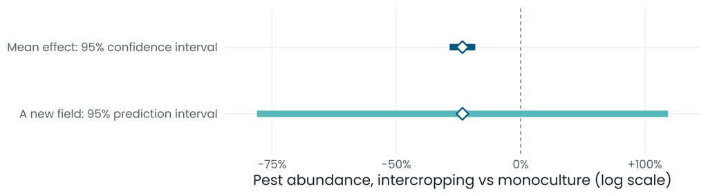

**CI**: -33% to -22% — how precisely we know the **average**. Shrinks as studies accumulate.

**PI**: -77% to +128% — where the effect in a **new** field is expected. Reflects τ²; does not shrink (IntHout et al. 2016).

## Quick quiz

**1.** I² = 0%. Are the true effects identical?

Not necessarily: with few, imprecise studies, heterogeneity is simply **not detectable**.

**2.** A farmer asks: “will intercropping reduce pests **on my farm**?” CI or PI?

**PI** — and here it includes increases.

**3.** τ = 0.58 on the lnRR scale. Small or large?

**Large**: mean ± 1 τ already spans -60% to +29%.

# Non-independence

## 382 comparisons are not 382 studies

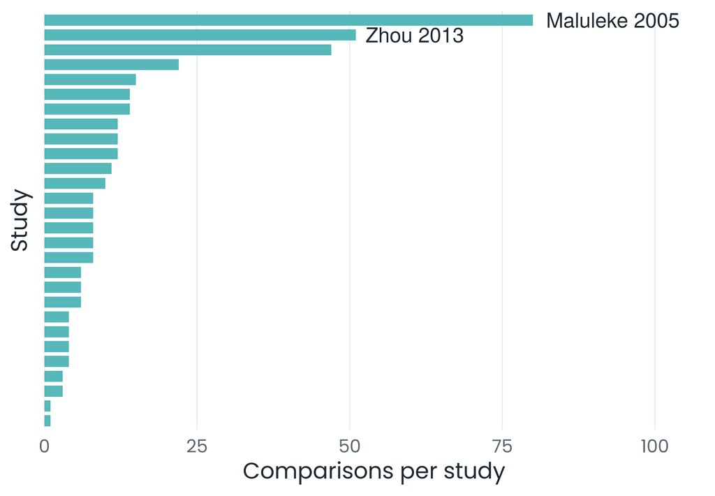

Several taxa, dates, sites or treatments **within the same study**: same team, same field, same weather, sometimes the **same control plots**.

Treating them as independent = **pseudo-replication**: CIs too narrow, studies with many comparisons over-weighted.

## The multilevel (three-level) model

$$y_{ij} = \mu + u_{j} + u_{ij} + \varepsilon_{ij}$$

- $u_{j}$: **between-study** variation, $\sigma^2_{study}$
- $u_{ij}$: **within-study** variation (between comparisons), $\sigma^2_{within}$
- $\varepsilon_{ij}$: sampling error, $v_{ij}$ (known)

`study_id / es_id` = rows **nested** in studies:

```r
rma.mv(yi, vi,
       random = ~ 1 | study_id / es_id,
       test = "t", dfs = "contain",
       data = dat)
```

Our pests Of the total variance, **52%** is **between studies** and **48%** **within studies** (multilevel I², Nakagawa and Santos (2012)):

$$I^2_{study} = \frac{\sigma^2_{study}}{\sigma^2_{study} + \sigma^2_{within} + \tilde v}$$

ṽ = a “typical” sampling variance.

`test = "t", dfs = "contain"`: t-based CIs whose degrees of freedom follow the number of **studies** (28 − 1 = 27), not of comparisons (381) — safer than z.

## Predict first

Show of hands

Same 382 comparisons, four models. Which one gives the **widest** confidence interval — and does the **mean** change much?

## Same data, four models

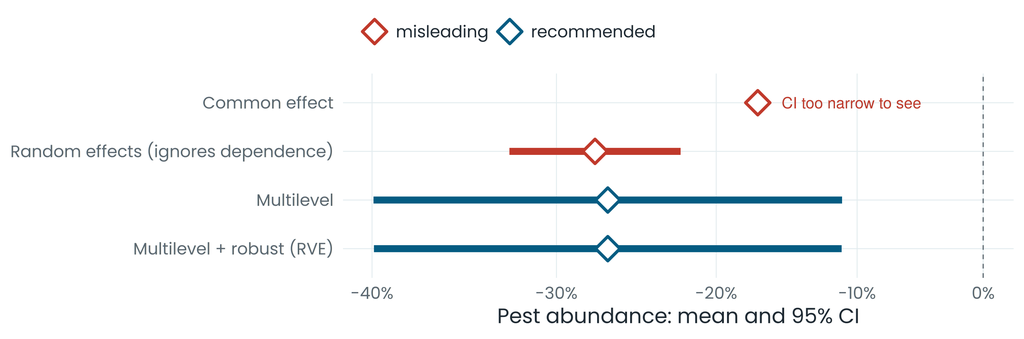

The first two models are **overconfident**: one study dominates (common effect) or 382 comparisons are treated as 382 studies.

**Robust variance estimation** (`robust()`, clustered by study) is a safety net when the dependence structure is uncertain (Pustejovsky and Tipton 2022). Needs ≳ 10–20 **studies**.

# Showing the results

## Beyond the forest plot: the orchard plot

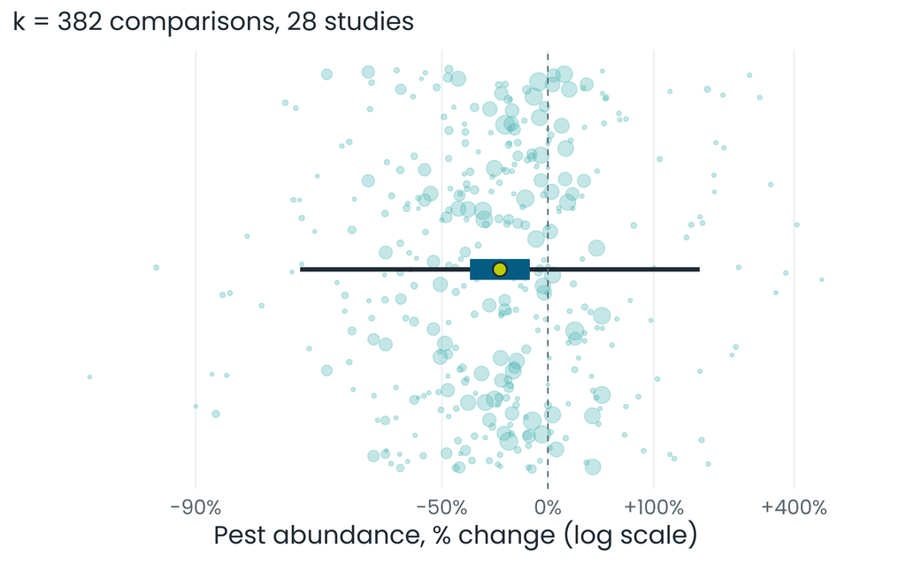

- **Points**: every comparison (`yi`), sized by precision
- **Thick bar**: 95% CI of the mean — `ci.lb`, `ci.ub`
- **Thin bar**: 95% prediction interval — `pi.lb`, `pi.ub`
- **Dot**: the mean — `pred` (all from `predict(model)`)
- **k** and number of studies

With hundreds of effect sizes, a classic forest plot is unreadable; the orchard plot shows **mean, uncertainty, heterogeneity and raw data** at once (Nakagawa et al. 2021).

## Practical · 33 min + debrief

| Time | Task |
| --- | --- |
| 14:22 | Common vs random effects: estimates and **weights** |
| 14:30 | Heterogeneity: τ², I², **prediction interval** |
| 14:38 | **Multilevel** model + `robust()` |
| 14:46 | **Orchard plot**, then *your turn*: change one word, rerun for natural enemies |
| 14:55 | **Debrief** (all together) |

Open **`meta_analysis_course.Rproj`** (the course kit), then **`td_models.R`**. Instructions and folded solutions: the practical web page.

## Key messages

1. Studies are **weighted** by precision; τ² (random effects) tames very precise studies, the **multilevel** model stops studies with many rows from dominating.
2. Choose the model **a priori**; in ecology: **random effects**, and **multilevel** when a study gives several effect sizes.
3. Report **μ with its CI, τ² and the prediction interval**; I² is relative, not a measure of how different effects are.
4. Show the data: **orchard plots**. *Next (15:00): are these 28 studies a biased sample?*

## In the online notebook

Each point of this session developed further, with the same data, more pitfalls and exercises with solutions:

- [Dependence: map it before you model it](https://literaturesynthesis.github.io/notebook/chapters/dependence.html)
- [Combining effect sizes: fixed, random and multilevel models](https://literaturesynthesis.github.io/notebook/chapters/combining-effect-sizes.html)
- [One question from start to finish](https://literaturesynthesis.github.io/notebook/chapters/worked-example.html)

**literaturesynthesis.github.io/notebook**

## References

Borenstein, M., L. V. Hedges, J. P. T. Higgins, and H. R. Rothstein. 2021. Introduction to meta-analysis. Second edition. Wiley, Chichester.

IntHout, J., J. P. A. Ioannidis, M. M. Rovers, and J. J. Goeman. 2016. [Plea for routinely presenting prediction intervals in meta-analysis](https://doi.org/10.1136/bmjopen-2015-010247). BMJ Open 6:e010247.

Jones, S. K., A. C. Sánchez, S. D. Juventia, and N. Estrada-Carmona. 2021. [A global database of diversified farming effects on biodiversity and yield](https://doi.org/10.1038/s41597-021-01000-y). Scientific Data 8:212.

Maluleke, M. H., A. Addo-Bediako, and K. K. Ayisi. 2005. [Influence of maize/lablab intercropping on lepidopterous stem borer infestation in maize](https://doi.org/10.1093/jee/98.2.384). Journal of Economic Entomology 98:384–388.

Nakagawa, S., M. Lagisz, R. E. O’Dea, J. Rutkowska, Y. Yang, D. W. A. Noble, and A. M. Senior. 2021. [The orchard plot: Cultivating a forest plot for use in ecology, evolution, and beyond](https://doi.org/10.1002/jrsm.1424). Research Synthesis Methods 12:4–12.

Nakagawa, S., and E. S. A. Santos. 2012. [Methodological issues and advances in biological meta-analysis](https://doi.org/10.1007/s10682-012-9555-5). Evolutionary Ecology 26:1253–1274.

Nakagawa, S., Y. Yang, E. L. Macartney, R. Spake, and M. Lagisz. 2023. [Quantitative evidence synthesis: A practical guide on meta-analysis, meta-regression, and publication bias tests for environmental sciences](https://doi.org/10.1186/s13750-023-00301-6). Environmental Evidence 12:8.

Pustejovsky, J. E., and E. Tipton. 2022. [Meta-analysis with robust variance estimation: Expanding the range of working models](https://doi.org/10.1007/s11121-021-01246-3). Prevention Science 23:425–438.

Rice, K., J. P. T. Higgins, and T. Lumley. 2018. [A re-evaluation of fixed effect(s) meta-analysis](https://doi.org/10.1111/rssa.12275). Journal of the Royal Statistical Society: Series A 181:205–227.

Senior, A. M., C. E. Grueber, T. Kamiya, M. Lagisz, K. O’Dwyer, E. S. A. Santos, and S. Nakagawa. 2016. [Heterogeneity in ecological and evolutionary meta-analyses: Its magnitude and implications](https://doi.org/10.1002/ecy.1591). Ecology 97:3293–3299.

Zhou, H.-B., J.-L. Chen, Y. Liu, F. Francis, E. Haubruge, C. Bragard, J.-R. Sun, and D.-F. Cheng. 2013. Influence of garlic intercropping or active emitted volatiles in releasers on aphid and related beneficial in wheat fields in China. Journal of Integrative Agriculture 12.